# HFT 2025

Author

Nihad & Vikram

Published

January 20, 2025

## Approaches undertaken

### Group 1

We used different SMA with entry/exit based on double volatility breakout using mean reverting strategies. The parameters in term of fast and slow moving averages we tried 60, 90, 120, 150 etc with various upper and lower rolling sds to define entry and entry. But we did not find the SR ration and net PnL very interesting.

Second strategy we tried based on pair trading using average closing price spread and sds of returns based spread. In this additionally first week of each quarter we used to iterate over various values of m, volat.sd for both types of spread and calculated the best parameters based on highest SR ratio. We did this for each week and moved the time frame to next week. So first week generally there is no trade and following weeks based on last week best parameters pair trading was performed.

### Finally selected strategy for **group 1**

Finally for group 1 we selected pair trading with previous weeks best parameters used for running week.

Sample parameters estimations for **2024 Quarter 2** (spread.name 1 (spread_avratio) and 2 (spread_sdsratio))

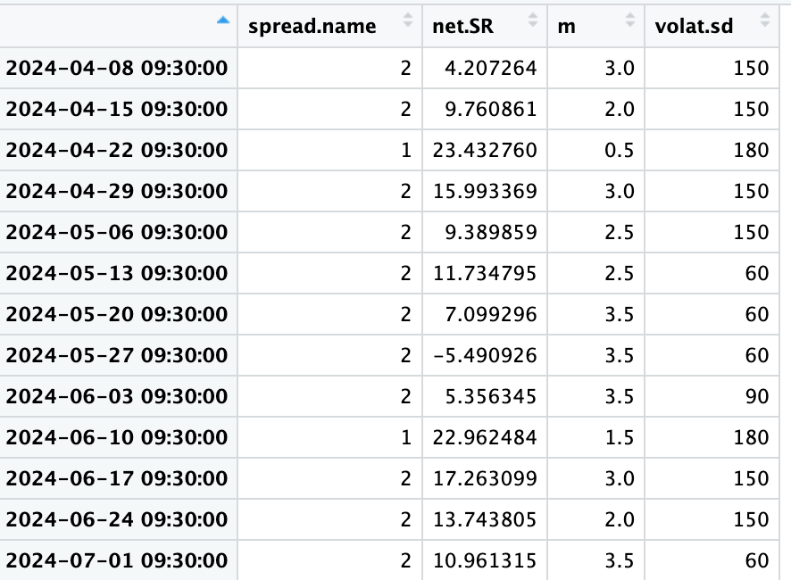

best_parameters_2024_q2

### Group 1 - 2022 first quarter results

matrix

| gross SR | net SR | gross CR | net CR | gross cumP&L | net cumP&L | av.ntrades |
| --- | --- | --- | --- | --- | --- | --- |
| -0.05446243 | -1.335636 | -0.1013886 | -1.978189 | -577.28 | -14452.74 | 4.644068 |

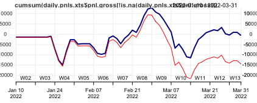

g1_q1_2022

### Group 1 - 2022 third quarter results

matrix

| gross SR | net SR | gross CR | net CR | gross cumP&L | net cumP&L | av.ntrades |
| --- | --- | --- | --- | --- | --- | --- |
| -0.2735316 | -0.8866143 | -0.5287689 | -1.530431 | -2837.795 | -9247.564 | 2.166667 |

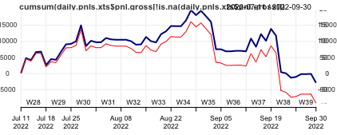

### Group 1 - 2022 fourth quarter results

matrix

| gross SR | net SR | gross CR | net CR | gross cumP&L | net cumP&L | av.ntrades |
| --- | --- | --- | --- | --- | --- | --- |
| 3.779882 | 2.572602 | 12.44741 | 7.09879 | 22419.65 | 14865.49 | 2.666667 |

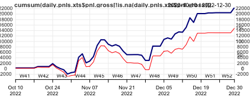

### Group 1 - 2023 Second quarter results

matrix

| gross SR | net SR | gross CR | net CR | gross cumP&L | net cumP&L | av.ntrades |
| --- | --- | --- | --- | --- | --- | --- |
| 6.971348 | 5.2925 | 44.56767 | 27.48605 | 53970.73 | 40750.74 | 4.3 |

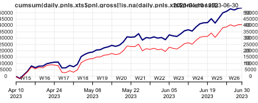

g1_q2_2023

### Group 1 - 2023 fourth quarter results

matrix

[output not shown]

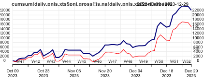

g1_q4_2023

### Group 1 - 2024 first quarter results

matrix

| gross SR | net SR | gross CR | net CR | gross cumP&L | net cumP&L | av.ntrades |
| --- | --- | --- | --- | --- | --- | --- |
| 2.561474 | 0.8205267 | 4.890218 | 1.070789 | 12773.7 | 3430.214 | 2.866667 |

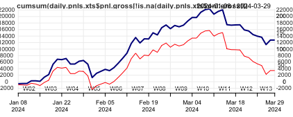

g1_q1_2024

### Group 1 - 2024 second quarter results

matrix

| gross SR | net SR | gross CR | net CR | gross cumP&L | net cumP&L | av.ntrades |
| --- | --- | --- | --- | --- | --- | --- |
| 0.8397483 | -0.8141622 | 2.26682 | -1.552525 | 4840.637 | -4716.803 | 2.933333 |

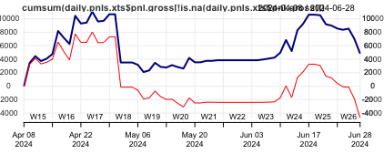

g1_q2_2024

## Group 1 - 2022-2024 quarterly results

```r
# Read the CSV file
data <- read.csv("final_results.csv")
```

```r
# Display the table
knitr::kable(data)
```

| X | Quarter.Name | Gross.SR | Net.SR | Gross.CR | Net.CR | Gross.cumP.L | Net.cumP.L | Av.ntrades | Stat |
| --- | --- | --- | --- | --- | --- | --- | --- | --- | --- |
| 1 | 2022_Q1 | -0.0544624 | -1.3356356 | -0.1013886 | -1.978188 | -577.280 | -14452.735 | 4.644068 | -5.283512 |
| 2 | 2022_Q3 | -0.2735316 | -0.8866143 | -0.5287689 | -1.530431 | -2837.795 | -9247.564 | 2.166667 | -3.404230 |
| 3 | 2022_Q4 | 3.7798816 | 2.5726020 | 12.4474066 | 7.098790 | 22419.653 | 14865.495 | 2.666667 | 19.159937 |
| 4 | 2023_Q2 | 6.9713478 | 5.2925002 | 44.5676697 | 27.486047 | 53970.728 | 40750.735 | 4.300000 | 101.903802 |
| 5 | 2023_Q4 | 4.2290601 | 2.8969007 | 27.1422746 | 14.412131 | 22088.172 | 14856.988 | 2.271186 | 38.890707 |
| 6 | 2024_Q1 | 2.5614741 | 0.8205267 | 4.8902179 | 1.070790 | 12773.703 | 3430.214 | 2.866667 | 1.319879 |
| 7 | 2024_Q2 | 0.8397483 | -0.8141622 | 2.2668195 | -1.552525 | 4840.637 | -4716.803 | 2.933333 | -2.408170 |

## Approaches undertaken

### Group 2

We used the different strategies including and excluding some assets. First of all, we tried based on pair trading using average closing price spread and standard deviation of returns based on spread dividing pairs by currencies(CAD&AUD) and metals(XAU&XAG). The results were not satisfactory.

Secondly, from fundamental perspective, we decided to omit CAD since It has positive relationship with USD which has negative relationship with XAU and It has similar trend pattern with AUD. In our strategy, we used momentum approach using 30 and 90 SMA for AUD and pair of XAU&XAG.

### Group 2- 2022 first quarter results

gross SR

net SR

gross CR

net CR

gross cumP&L

net cumP&L

av.ntrades

```
-0.08796367
```

```
-0.3203243
```

```
-0.1287973
```

```
-0.4405723
```

```
-59418.29
```

```
-215532.6
```

```
4.611111
```

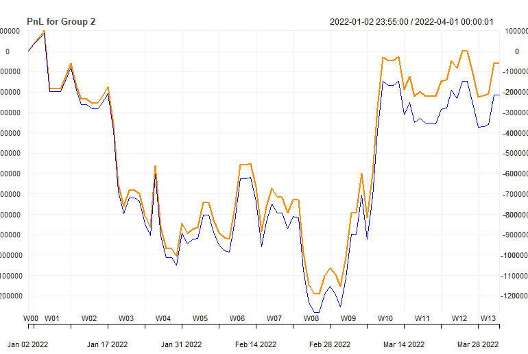

g2_q1_2022

In the first quarter of 2022, our strategy concluded with negative PnL due to high volatility and Its stat value is -2.3672.

### Group 2 - 2022 third quarter results

gross SR

net SR

gross CR

net CR

gross cumP&L

net cumP&L

av.ntrades

```
1.00793395
```

```
0.7994004
```

```
 2.2682883
```

```
1.6832033
```

```
838372.21
```

```
661778.9
```

```
4.763441
```

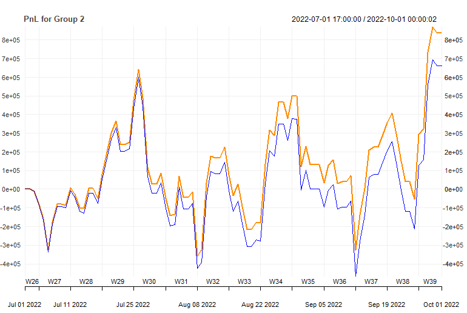

In the third quarter of 2022, our strategy concluded with profit and Its stat value is 10,9323.

### Group 2 - 2022 fourth quarter results

gross SR

net SR

gross CR

net CR

gross cumP&L

net cumP&L

av.ntrades

```
-0.28367666
```

```
-0.4872866
```

```
-0.5528670
```

```
-0.9162963
```

```
-238877.84
```

```
-408326.5
```

```
4.901099
```

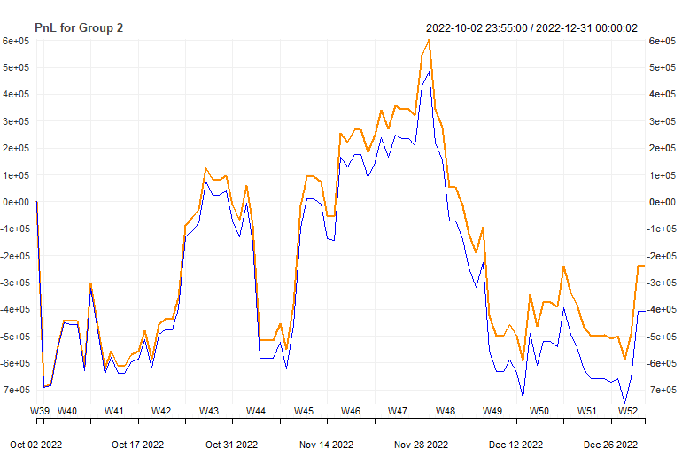

g2_q4_2022

In the 4th quarter of 2022, our strategy was unsuccesfull, so Its stat value is -5.5088.

### Group 2 - 2023 Second quarter results

[output not shown]

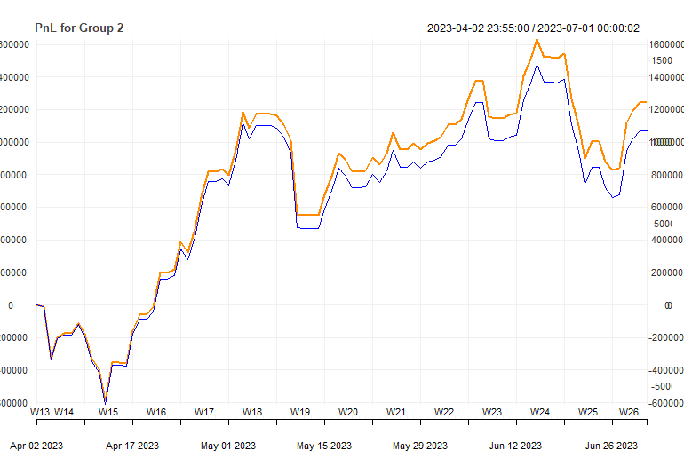

g2_q2_2023

In the second quarter of 2023, our stratgey concluded with success and its stat value 25.6372.

### Group 2 - 2023 Fourth quarter results

| gross SR | net SR | gross CR | net CR | gross cumP&L | net cumP&L | av.ntrades |
| --- | --- | --- | --- | --- | --- | --- |
| 0.4194 | 0.1852 | 0.9724 | 0.4112 | 323969.7207 | 142276.2714 | 5.0444 |

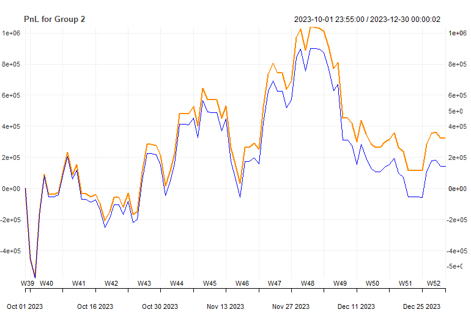

g2_q4_2023

In the fiurth quarter of 2023, our strategy was successfull with 2.0388 stat value.

### Group 2 - 2024 First quarter results

| gross SR | net SR | gross CR | net CR | gross cumP&L | net cumP&L | av.ntrades |
| --- | --- | --- | --- | --- | --- | --- |
| -0.1721 | -0.4597 | -0.4496 | -1.0528 | -103307.4365 | -274562.6246 | 4.6957 |

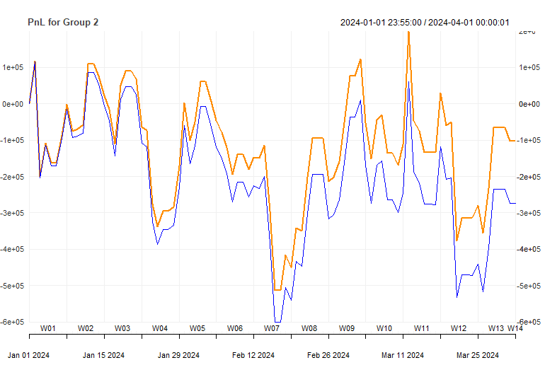

In the first quarter of 2024, our strategy concluded with negative PnL and Its stat value is -5,9118.

### Group 2 - 2024 Second quarter results

| gross SR | net SR | gross CR | net CR | gross cumP&L | net cumP&L | av.ntrades |
| --- | --- | --- | --- | --- | --- | --- |
| 1.1043 | 0.98689 | 1.8792 | 1.662 | 1670146.1874 | 1487773.1757 | 5.0326 |

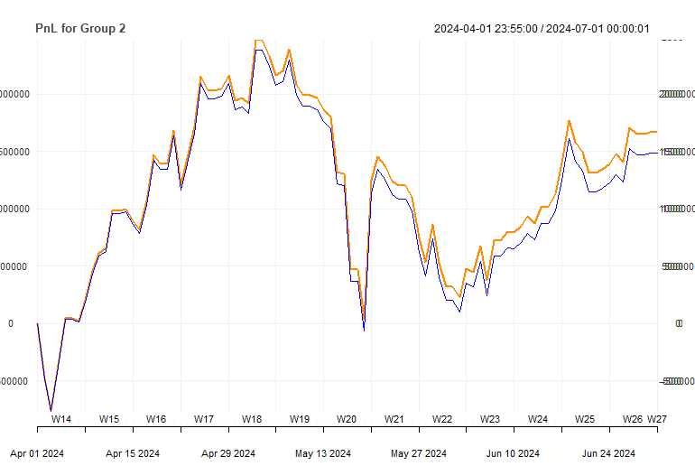

In the second quarter of 2024, our strategy concluded with positive PnL and Its stat value is 12.1413.

## Group 2 - 2022-2024 quarterly results

```r
data1 <- read.csv("quarter_stats.all.group2.csv")
```

| quarter | assets.group | grossSR | netSR | grossCR | netCR | av.daily.ntrades | grossPnL | netPnL | stat |
| --- | --- | --- | --- | --- | --- | --- | --- | --- | --- |
| 2022_Q1 | 2 | -0.0880 | -0.3203 | -0.1288 | -0.4406 | 4.6111 | -59418.29 | -215532.6 | -2.3672 |
| 2022_Q3 | 2 | 1.0079 | 0.7994 | 2.2683 | 1.6832 | 4.7634 | 838372.21 | 661778.9 | 10.9323 |
| 2022_Q4 | 2 | -0.2837 | -0.4873 | -0.5529 | -0.9163 | 4.9011 | -238877.84 | -408326.5 | -5.5088 |
| 2023_Q2 | 2 | 1.8185 | 1.5756 | 4.3407 | 3.6753 | 5.1556 | 1243477.03 | 1070183.7 | 25.6372 |
| 2023_Q4 | 2 | 0.4194 | 0.1852 | 0.9724 | 0.4112 | 5.0440 | 323969.72 | 142276.3 | 2.0388 |
| 2024_Q1 | 2 | -0.1721 | -0.4597 | -0.4496 | -1.0528 | 4.6957 | -103307.44 | -274562.6 | -5.9118 |
| 2024_Q2 | 2 | 1.1043 | 0.9869 | 1.8792 | 1.6620 | 5.0326 | 1670146.19 | 1487773.2 | 12.1413 |